# Lab4

Clayton Curry

2020-09-18

# Task 1

```r
getwd()
```

```
## [1] "C:/Dev/R_Projects/MATH4753CURR0011/Labs/Lab04"
```

# Task 2

```r
spruce.df <- read.table("SPRUCE.csv", header = TRUE, sep = ",")
tail(spruce.df)
```

```
##    BHDiameter Height
## 31       17.7   19.9
## 32       20.7   19.4
## 33       21.0   20.4
## 34       13.3   15.5
## 35       15.9   17.6
## 36       22.9   19.2
```

# Task 3

## Lowess smoother scatter plot

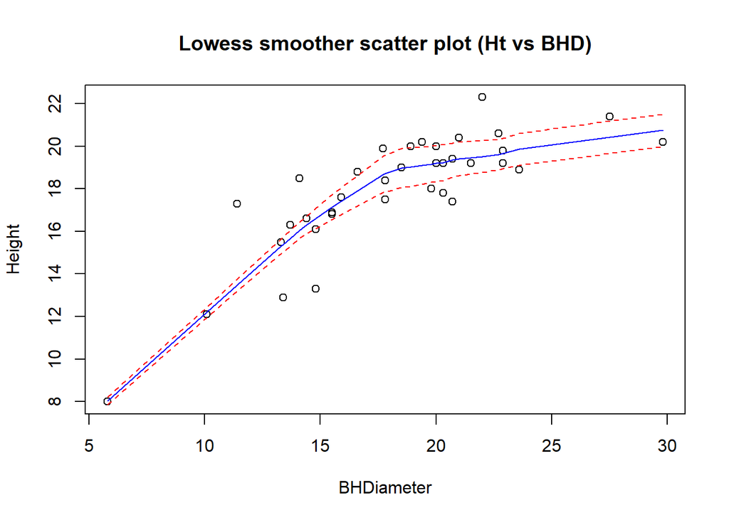

```r
library(s20x)
trendscatter(Height~BHDiameter, data = spruce.df, f = 0.5, main = "Lowess smoother scatter plot (Ht vs BHD)")
```

## Make a linear model object

```r
spruce.lm = with(spruce.df, lm(Height~BHDiameter))
```

## Find residuals using residuals(), put them into an object called height.res

```r
height.res = residuals(spruce.lm)
```

## Find the fitted values using fitted(), and place them in an object called height.fit.

```r
height.fit = fitted(spruce.lm)
```

## Plot the Residuals vs. Fitted

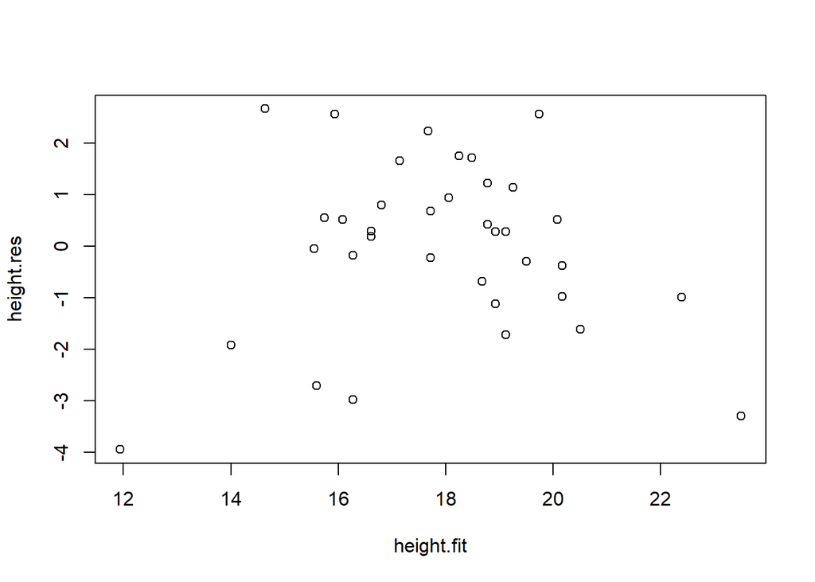

```r
plot(x = height.fit, y = height.res)
```

## Plot the residuals vs fitted using trendscatter()

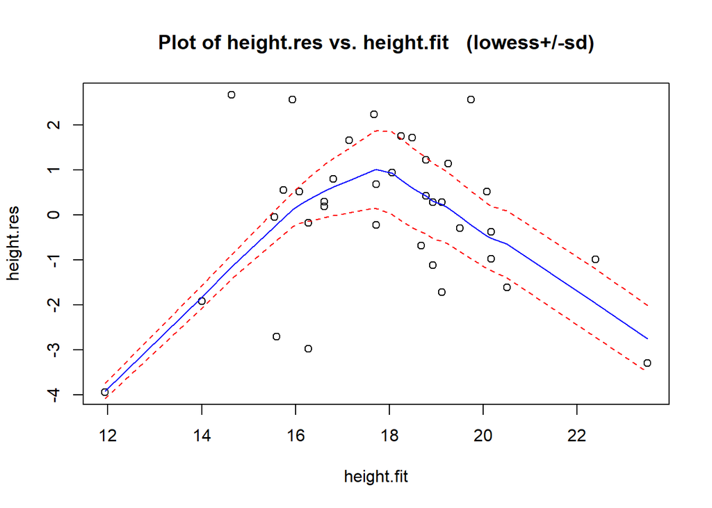

```r
trendscatter(x = height.fit, y=height.res)
```

## Residual plot

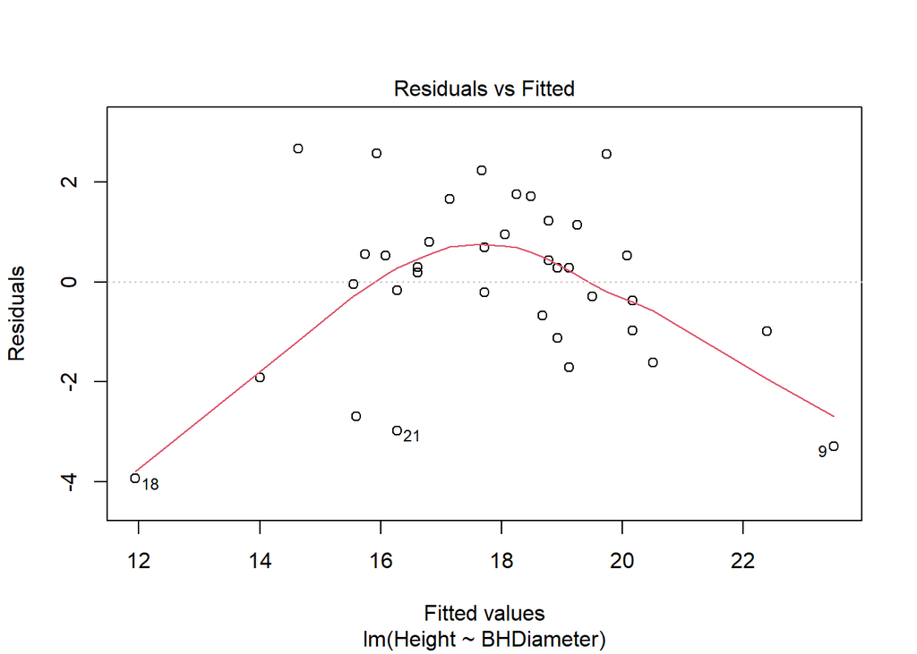

```r
plot(spruce.lm, which = 1)
```

## Check normality

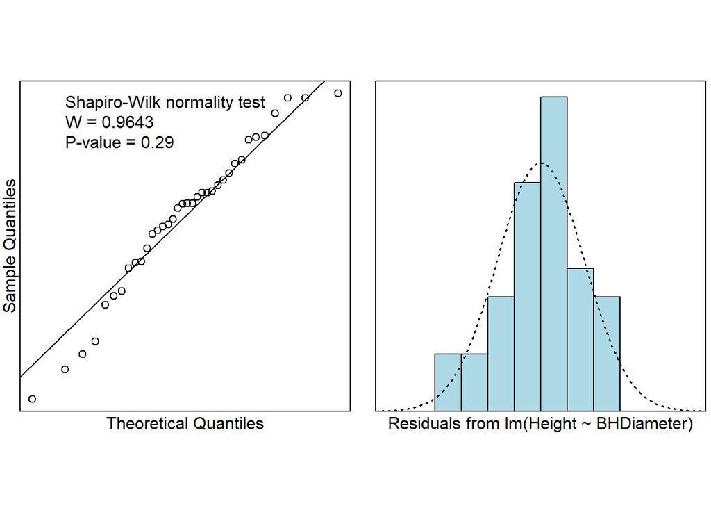

```r
normcheck(spruce.lm, shapiro.wilk = TRUE)
```

## P-Value and Null-Hypothesis

Because the p=value is greater than 0.05, we accept the null hypothesis which says our error is distributed normally.

Lab 4 manual states, “we should expect that the residuals are approximately Normal in distribution if the model works well with the data,” which is what the Shapiro-Wilk test shows.

## Evaluating the model

```r
round(mean(height.res), 4)
```

```
## [1] 0
```

The mean is 0 for the residuals. ## Conclusion Given the distribution of residuals about the fitted-line model is normal, we have strong evidence to conclude that we should not use a straight line model.

# Task 4

## Fit a quadratic

```r
quad.lm = lm(Height~BHDiameter+I(BHDiameter^2), data = spruce.df)

summary(quad.lm)
```

```
##
## Call:
## lm(formula = Height ~ BHDiameter + I(BHDiameter^2), data = spruce.df)
##
## Residuals:
##     Min      1Q  Median      3Q     Max
## -3.2966 -0.6245 -0.0707  0.7442  3.2541
##
## Coefficients:
##                  Estimate Std. Error t value Pr(>|t|)
## (Intercept)      0.860896   2.205022   0.390 0.698731
## BHDiameter       1.469592   0.243786   6.028 8.88e-07 ***
## I(BHDiameter^2) -0.027457   0.006635  -4.138 0.000227 ***
## ---
## Signif. codes:  0 '***' 0.001 '**' 0.01 '*' 0.05 '.' 0.1 ' ' 1
##
## Residual standard error: 1.382 on 33 degrees of freedom
## Multiple R-squared:  0.7741, Adjusted R-squared:  0.7604
## F-statistic: 56.55 on 2 and 33 DF,  p-value: 2.182e-11
```

## Make a fresh plot and add quadratic curve

```r
coef(quad.lm)
```

```
##     (Intercept)      BHDiameter I(BHDiameter^2)
##      0.86089580      1.46959217     -0.02745726
```

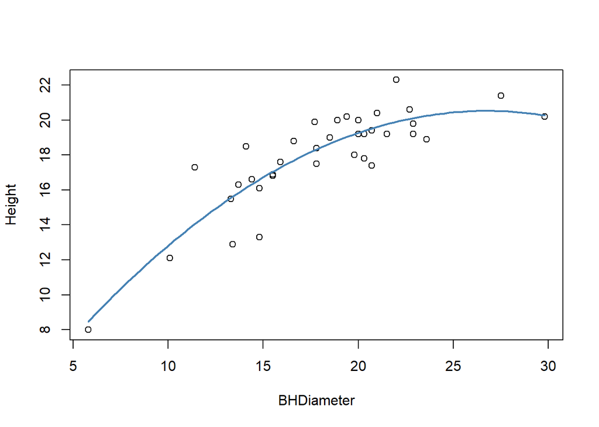

```r
plot(spruce.df)

myplot = function(x)
{
  quad.lm$coef[1]  + quad.lm$coef[2] * x + quad.lm$coef[3] * x ^ 2
}

curve(myplot, lwd = 2, col = "steelblue", add = TRUE)
```

## Make quad. fit

```r
quad.fit = fitted(quad.lm)
```

## Residuals vs. Fitted

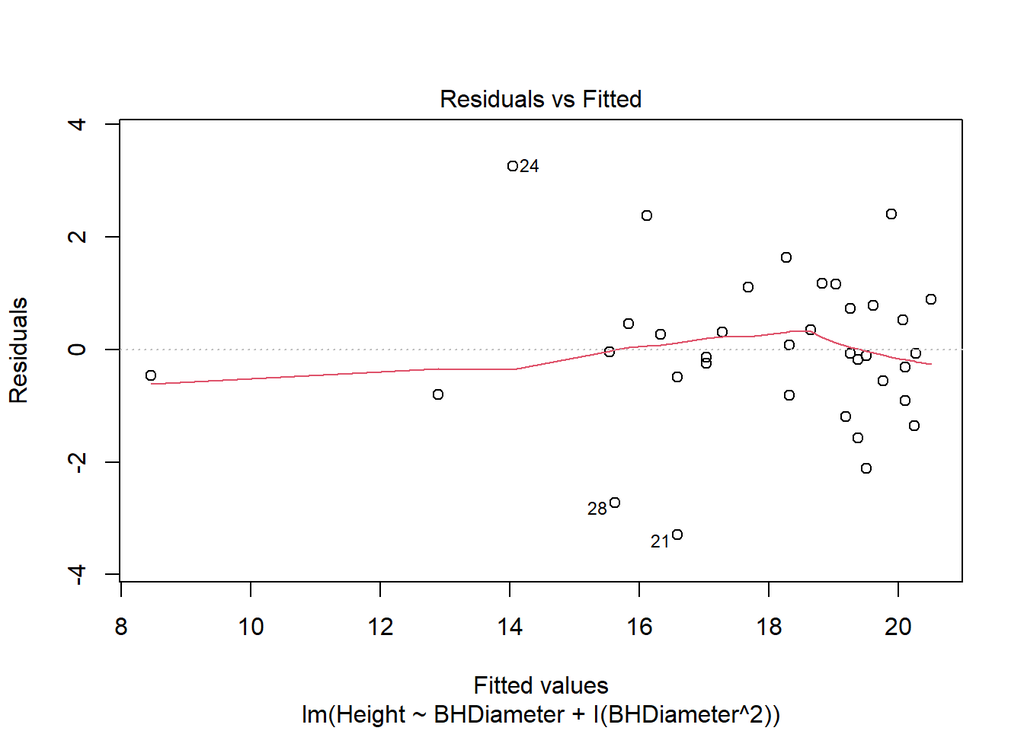

```r
plot(quad.lm, which = 1)
```

## Check normality

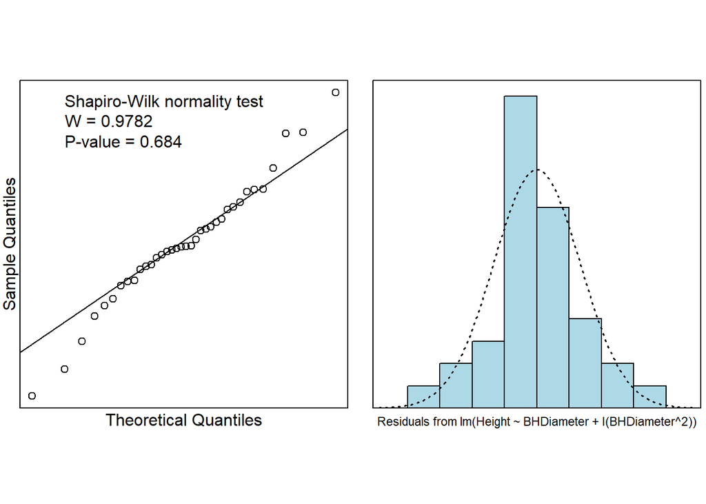

```r
normcheck(quad.lm, shapiro.wilk = TRUE)
```

## Conclusion

The p-value is 0.684. Therefore, we accept the null hypothesis.

Based on the residuals vs. fitted values plot from quad.lm, there is not much of a trend. Also, the residuals go from about -4 to 4. We have achieved a level of “noise” with no extra signal.

# Task 5

## Summarize quad.lm

```r
summary(quad.lm)
```

```
##
## Call:
## lm(formula = Height ~ BHDiameter + I(BHDiameter^2), data = spruce.df)
##
## Residuals:
##     Min      1Q  Median      3Q     Max
## -3.2966 -0.6245 -0.0707  0.7442  3.2541
##
## Coefficients:
##                  Estimate Std. Error t value Pr(>|t|)
## (Intercept)      0.860896   2.205022   0.390 0.698731
## BHDiameter       1.469592   0.243786   6.028 8.88e-07 ***
## I(BHDiameter^2) -0.027457   0.006635  -4.138 0.000227 ***
## ---
## Signif. codes:  0 '***' 0.001 '**' 0.01 '*' 0.05 '.' 0.1 ' ' 1
##
## Residual standard error: 1.382 on 33 degrees of freedom
## Multiple R-squared:  0.7741, Adjusted R-squared:  0.7604
## F-statistic: 56.55 on 2 and 33 DF,  p-value: 2.182e-11
```

## Beta hat values

$$\hat{\beta}_0 = 0.860896, \hat{\beta_1}=1.469592, \hat{\beta_2} = -0.027457$$

## Interval estimates

```r
ciReg(quad.lm)
```

```
##                 95 % C.I.lower    95 % C.I.upper
## (Intercept)           -3.62525           5.34705
## BHDiameter             0.97361           1.96558
## I(BHDiameter^2)       -0.04096          -0.01396
```

## Equation of fitted line

$$\hat{Height}= 0.860896+1.469592x -0.027457x^2$$
## Height predictions

```r
predict(quad.lm, data.frame(BHDiameter = c(15,18,20)))
```

```
##        1        2        3
## 16.72690 18.41740 19.26984
```

## Comparison

```r
predict(spruce.lm, data.frame(BHDiameter = c(15,18,20)))
```

```
##        1        2        3
## 16.36895 17.81338 18.77632
```

## Multiple R-squared

### quad.lm

```r
summary(quad.lm)$r.squared
```

```
## [1] 0.7741266
```

$$R^2 = 0.7741266$$

### spruce.lm

```r
summary(spruce.lm)$r.squared
```

```
## [1] 0.6569146
```

$$R^2=0.6569146$$

## Adjusting R-squared

```r
summary(quad.lm)$adj.r.squared
```

```
## [1] 0.7604373
```

```r
summary(spruce.lm)$adj.r.squared
```

```
## [1] 0.6468239
```

## Meaning of multiple R-squared

The adjusted R-squared inducates how well data fits a model. Variables for such detemination include the variablility of residuals and the number of data points.

Bigger $R^2$ = better model. Hence, based on the R-squared values, quad.lm is a better fit. ## Model with most variability

```r
summary(quad.lm)$r.squared
```

```
## [1] 0.7741266
```

```r
summary(quad.lm)$adj.r.squared
```

```
## [1] 0.7604373
```

```r
summary(spruce.lm)$r.squared
```

```
## [1] 0.6569146
```

```r
summary(spruce.lm)$adj.r.squared
```

```
## [1] 0.6468239
```

## anova

```r
anova(spruce.lm)
```

```
## Analysis of Variance Table
##
## Response: Height
##            Df  Sum Sq Mean Sq F value    Pr(>F)
## BHDiameter  1 183.245 183.245  65.101 2.089e-09 ***
## Residuals  34  95.703   2.815
## ---
## Signif. codes:  0 '***' 0.001 '**' 0.01 '*' 0.05 '.' 0.1 ' ' 1
```

```r
anova(quad.lm)
```

```
## Analysis of Variance Table
##
## Response: Height
##                 Df  Sum Sq Mean Sq F value    Pr(>F)
## BHDiameter       1 183.245 183.245  95.975 2.701e-11 ***
## I(BHDiameter^2)  1  32.696  32.696  17.125 0.0002269 ***
## Residuals       33  63.007   1.909
## ---
## Signif. codes:  0 '***' 0.001 '**' 0.01 '*' 0.05 '.' 0.1 ' ' 1
```

```r
anova(spruce.lm, quad.lm)
```

```
## Analysis of Variance Table
##
## Model 1: Height ~ BHDiameter
## Model 2: Height ~ BHDiameter + I(BHDiameter^2)
##   Res.Df    RSS Df Sum of Sq      F    Pr(>F)
## 1     34 95.703
## 2     33 63.007  1    32.696 17.125 0.0002269 ***
## ---
## Signif. codes:  0 '***' 0.001 '**' 0.01 '*' 0.05 '.' 0.1 ' ' 1
```

The quad.lm better suits the data, due to its lower RSS than spruce.lm.

## TSS, MSS, RSS

```r
height.qfit = fitted(quad.lm)
```

### TSS

```r
TSS = with(spruce.df, sum((Height - mean(Height))^2))
TSS
```

```
## [1] 278.9475
```

### MSS

```r
MSS = with(spruce.df, sum((height.qfit - mean(Height))^2))
MSS
```

```
## [1] 215.9407
```

### RSS

```r
RSS = with(spruce.df, sum((Height - height.qfit) ^ 2))
RSS
```

```
## [1] 63.00683
```

## MSS/TSS

```r
MSS/TSS
```

```
## [1] 0.7741266
```

# Task 6

## Cook’s Plot

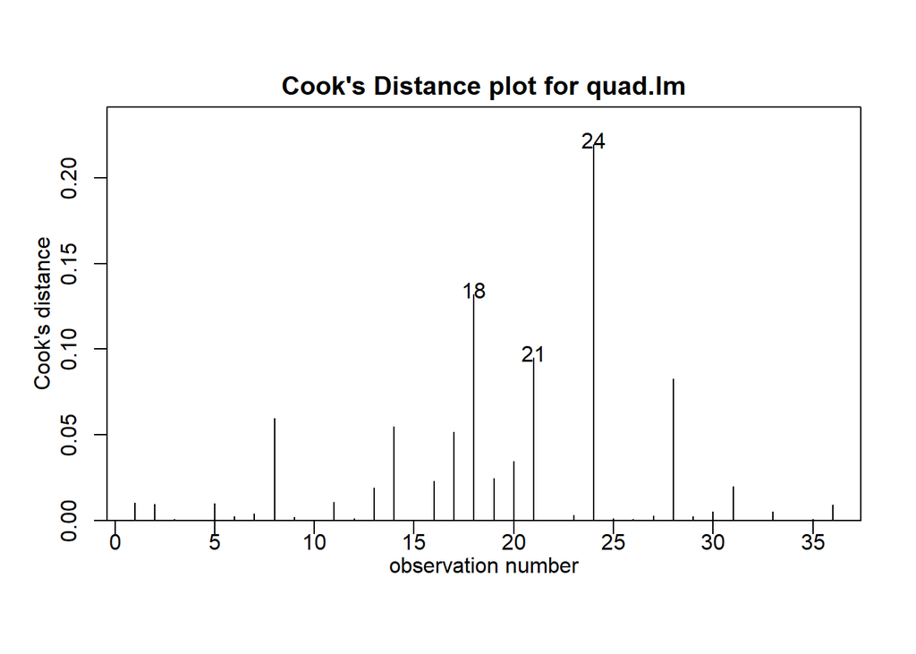

```r
cooks20x(quad.lm, main = "Cook's Distance plot for quad.lm")
```

## What Cook’s distance is

It is important to consider the highest point indicated by Cook’s plot given that the score indicates the datum having the highest impact on the estimation of parameters of a population.

If this datum is unreliable, then the whole analysis will be skewed.

## quad2.lm

```r
quad2.lm = lm(Height~BHDiameter + I(BHDiameter ^ 2), data = spruce.df[-24,])
```

## quad2.lm summary

```r
summary(quad2.lm)
```

```
##
## Call:
## lm(formula = Height ~ BHDiameter + I(BHDiameter^2), data = spruce.df[-24,
##     ])
##
## Residuals:
##      Min       1Q   Median       3Q      Max
## -3.11233 -0.48227  0.01253  0.71727  2.59146
##
## Coefficients:
##                  Estimate Std. Error t value Pr(>|t|)
## (Intercept)     -0.341500   2.068479  -0.165     0.87
## BHDiameter       1.564793   0.226102   6.921 7.78e-08 ***
## I(BHDiameter^2) -0.029242   0.006114  -4.782 3.74e-05 ***
## ---
## Signif. codes:  0 '***' 0.001 '**' 0.01 '*' 0.05 '.' 0.1 ' ' 1
##
## Residual standard error: 1.266 on 32 degrees of freedom
## Multiple R-squared:  0.8159, Adjusted R-squared:  0.8044
## F-statistic: 70.91 on 2 and 32 DF,  p-value: 1.74e-12
```

## Comparison with quad.lm

```r
summary(quad.lm)
```

```
##
## Call:
## lm(formula = Height ~ BHDiameter + I(BHDiameter^2), data = spruce.df)
##
## Residuals:
##     Min      1Q  Median      3Q     Max
## -3.2966 -0.6245 -0.0707  0.7442  3.2541
##
## Coefficients:
##                  Estimate Std. Error t value Pr(>|t|)
## (Intercept)      0.860896   2.205022   0.390 0.698731
## BHDiameter       1.469592   0.243786   6.028 8.88e-07 ***
## I(BHDiameter^2) -0.027457   0.006635  -4.138 0.000227 ***
## ---
## Signif. codes:  0 '***' 0.001 '**' 0.01 '*' 0.05 '.' 0.1 ' ' 1
##
## Residual standard error: 1.382 on 33 degrees of freedom
## Multiple R-squared:  0.7741, Adjusted R-squared:  0.7604
## F-statistic: 56.55 on 2 and 33 DF,  p-value: 2.182e-11
```

## Conclusion

By removing the datum, the R-squared value went up, meaning that the model better fits the data.

# Task 7

## Proof

Given two lines containing the point $x_k$,
$$\begin{eqnarray}
\ell_1: y &=& \beta_0 + \beta_1x \newline
\ell_2: y &=& \beta_0 + \delta+(\beta_1+\beta_2)x
\end{eqnarray}$$
We have the following equality since both lines contain $x_i$,
$$\beta_0 + \beta_1x_k = \beta_0 + \delta+(\beta_1+\beta_2)x_k$$
Distributing $x_k$ on the right hand side and by rearrangement,
$$\beta_0+\beta_1x_k=\beta_0+\delta+\beta_1x_k+\beta_2x_k \implies 0=\delta+\beta_2x_k \implies \delta=-\beta_2x_k$$

substituting back to $\ell_2$ for any x,

$$y = \beta_0 + \delta+(\beta_1+\beta_2)x \implies y = \beta_0 -\beta_2x_k +(\beta_1+\beta_2)x
\implies y = \beta_0 + \beta_1x + \beta_2(x-x_k)$$

We can now use an indicator function to allow our function to know where it should and should not include the adjustment.

$$y = \beta_0 + \beta_1x + \beta_2(x-x_k)I(x > x_k) \hspace{6pt} \text{where} \hspace{6pt}
\begin{equation*}
I(x)=\begin{cases}
1 \quad &\text{if} \, \hspace{4pt} x > x_k \\
0 \quad &\text{if} \, \hspace{4pt} x \le x_k\\
\end{cases}
\end{equation*}$$

## Reproducing plot

```r
sp2.df = within(spruce.df, X<-(BHDiameter - 18)*(BHDiameter > 18))

sp2.df
```

```
##    BHDiameter Height    X
## 1        18.9   20.0  0.9
## 2        16.6   18.8  0.0
## 3        15.5   16.8  0.0
## 4        15.5   16.9  0.0
## 5        19.4   20.2  1.4
## 6        13.7   16.3  0.0
## 7        20.0   20.0  2.0
## 8        27.5   21.4  9.5
## 9        29.8   20.2 11.8
## 10       20.3   19.2  2.3
## 11       19.8   18.0  1.8
## 12       22.9   19.8  4.9
## 13       20.3   17.8  2.3
## 14       14.1   18.5  0.0
```

[output cut: 22 more lines]

```r
lmp = lm(Height~BHDiameter + X, data = sp2.df)
tmp = summary(lmp)
names(lmp)
```

```
##  [1] "coefficients"  "residuals"     "effects"       "rank"
##  [5] "fitted.values" "assign"        "qr"            "df.residual"
##  [9] "xlevels"       "call"          "terms"         "model"
```

```r
myff = function(x, coef){
  coef[1] + coef[2] * (x) + coef[3] * (x-18) * (x-18>0)
}
plot(spruce.df, main = "Piecewise Regression")
myff(0, coef = tmp$coefficients[,"Estimate"])
```

```
## (Intercept)
##    4.499237
```

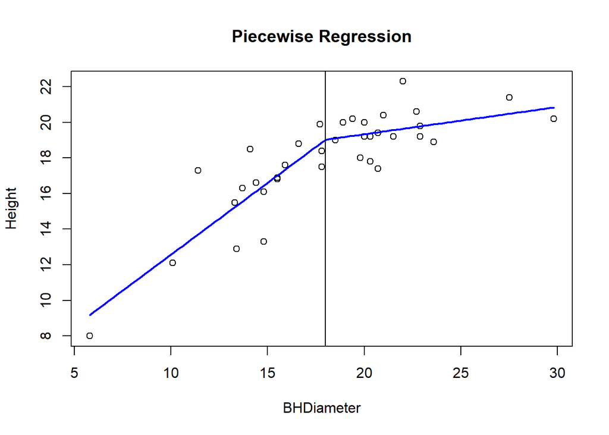

```r
curve(expr = myff(x, coef = tmp$coefficients[,"Estimate"]), add = TRUE, lwd = 2, col = "Blue")
abline(v = 18)
text(18, 6, paste("R sq.=", round(tmp$r.squared,4)))
```

# Task 8

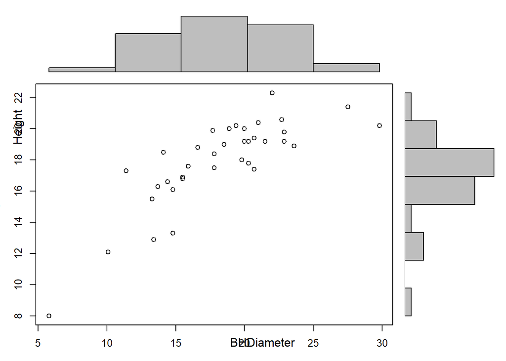

```r
library(MATH4753CURR0011)
myScatterhist(x = spruce.df$BHDiameter, y=spruce.df$Height, xlab = "BHDiameter", ylab = "Height")
```